# Practical Machine Learning Prediction Assignment

Seng-Shi Deng

10/25/2020

## Overview

Nowadays, people can now collect a large amount of personal activity data rather inexpensively. Most of the time, measurements are being used to quantify how much of an activity is being done. However, almost no consideration is given to how well an activity is being performed. The goal of this project will be to use data from accelerometers on the belt, forearm, and dumbbells of 6 participants who were asked to perform barbell lifts correctly and incorrectly in 5 different ways. The goal of this project is to predict the manner in which they did the exercise.

**Note**: More information on the research done for the activities referenced above can be found at: Velloso, E.; Bulling, A.; Gellersen, H.; Ugulino, W.; Fuks, H. *Qualitative Activity Recognition of Weight Lifting Exercises. Proceedings of 4th International Conference in Cooperation with SIGCHI (Augmented Human ’13)*. Stuttgart, Germany: ACM SIGCHI, 2013.

## Initial Processes

This section includes all the code that is needed before the Loading and Preprocessing section of the project, to include loading the necessary libraries, checking/creating a folder, setting up parallel processing, and a working directory, checking for the existence of the training and testing data in question. If they do not, they are downloaded accordingly. In addition, the data are read and two data frame objects are created.

```r
library(caret)
library(doParallel)
library(parallel)
library(rattle)
library(rpart)
library(scales)

# Initiate cluster #
cl <- makeCluster(detectCores(), type='PSOCK')

# Register the cluster #
registerDoParallel(cl)

# Checks to see if the data set folder exists in the working directory #
if(!file.exists("WLE Dataset")){
        dir.create("WLE Dataset")
}

# Sets the working directory to the new path #
setwd("./WLE Dataset")

# URLs of each of the data sets used #
trng_url <- "https://d396qusza40orc.cloudfront.net/predmachlearn/pml-training.csv"
tstng_url <- "https://d396qusza40orc.cloudfront.net/predmachlearn/pml-testing.csv"

# A character vector of the URLs of each of the datasets used #
ds_paths <- c(trng_url, tstng_url)

# Name of the files for each of the data sets used #
trng_ds <-"pml-training.csv"
tstng_ds <- "pml-testing.csv"

# A character vector of the name of the files of each of the data sets used #
DataSets <- c(trng_ds, tstng_ds)

# The number of datasets to examine #
numDS <- length(DataSets)

# This for loop checks to see if both of the data set files exists. If not, it #
# downloads the file. #
for(i in 1:numDS){
    if ((!file.exists(DataSets[i]))){
        download.file(url = ds_paths[i], destfile = DataSets[i] , method = "curl")
    }
}

# The names of the data set data frame objects. #
DS_names <- c("trng", "tstng")

# This for loops assigns the respective data frames the names listed above. #
for(j in 1:numDS){
        assign(DS_names[j], read.csv(DataSets[j], header = TRUE))
}
```

Next, basic exploratory analysis is performed.

```r
# Perform basic exploratory analysis #
str(trng)
str(tstng)
```

The output of the code above was omitted because of length consideration. However, upon examining the structures of both the testing and training data frames, there are many variables that are populated with NAs. Since missing data can drastically impact a machine learning model, these columns will be removed accordingly. From inspection of the structures of the data frames, it is apparent that the first seven variables of the data sets are unnecessary for any machine learning model chosen; therefore, these columns will also be eliminated. In addition it is also important to remove the near zero covariates of the training data frame.

## Data Transformation

It is necessary to prepare the data to be usable by the various machine learning models. To that end, these are the preparation steps taken:

```r
# Removing the NAs from the training and testing data frames #
trng <- trng[, colSums(is.na(trng)) == 0]
tstng <- tstng[, colSums(is.na(tstng)) == 0]

# Removing the first seven columns #
trng <- trng[, -c(1:7)]
tstng <- tstng[, -c(1:7)]

# Identifying the near zero covariates of the training data frame #
nv <- nearZeroVar(trng)

# Removing the above referenced covariates from the data frame #
trng <- trng[, -nv]

# Coercing the classe variable into a factor. #
trng$classe <- as.factor(trng$classe)

# Checking the dimensions of the data sets. #
dim(trng)
```

```
## [1] 19622    53
```

```r
dim(tstng)
```

```
## [1] 20 53
```

Since the classe variable is being used as the response variable, it is more convenient to coerce this variable into a factor object. Also, the testing and training data frames have been pare down to 53 variables.

## Data Splitting

The next step is to prepare the training data frame for both testing and testing by the various machine learning models, and thus the following is done:

```r
# Setting seed for reproducibility #
set.seed(1973)

# Creates training set that indexes 80% of the data #
inTrain <- createDataPartition(y = trng$classe, p = 0.8, list = FALSE)

# subset the training object into training data set #
trngDS <- trng[inTrain, ]

# subset the rest into testing data set #
tstngDS <- trng[-inTrain, ]
```

## Visualization

To gain a better understanding of the predictors of the training data set, the featurePlot() function of the Caret package is used:

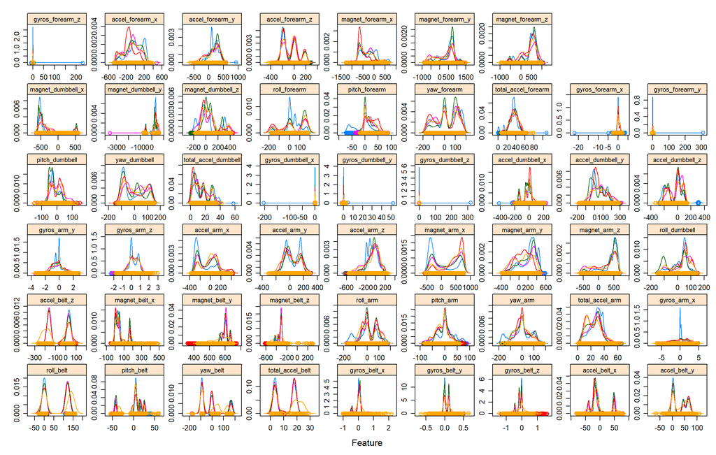

```r
# Graphical representation of predictor variables' importance to response #
# variable #
featurePlot(x = trngDS[, 1:52],
            y = trngDS$classe,
            plot = "density",
            strip=strip.custom(par.strip.text=list(cex=.7)),
            scales = list(x = list(relation="free"),
                          y = list(relation="free")))
```

To extract which variables are most important from a density feature plot, it is necessary to discern the significant difference in the 5 classes in terms of height(kurtosis) and placement(skewness). However, this isn’t easy to do visually. Therefore, we can perform a recursive feature elimination courtesy of the Caret package.

```r
options(warn=-1)

subsets <- c(1:5, 10, 15, 20, 25, 30, 35, 40, 45, 50, 52)

ctrl <- rfeControl(functions = rfFuncs,
                   method = "repeatedcv",
                   number = 5,
                   repeats = 5,
                   verbose = FALSE,
                   allowParallel = TRUE)

mdlProfile <- rfe(x = trngDS[, 1:52], y = trngDS$classe,
                  sizes = subsets,
                  rfeControl = ctrl)

mdlProfile
```

```
##
## Recursive feature selection
##
## Outer resampling method: Cross-Validated (5 fold, repeated 5 times)
##
## Resampling performance over subset size:
##
##  Variables Accuracy  Kappa AccuracySD  KappaSD Selected
##          1   0.4962 0.3468  0.0156019 0.021490
##          2   0.7260 0.6527  0.0092183 0.011580
##          3   0.8886 0.8590  0.0039956 0.005063
##          4   0.9421 0.9268  0.0030488 0.003855
##          5   0.9647 0.9554  0.0026505 0.003354
##         10   0.9872 0.9838  0.0041495 0.005249
##         15   0.9889 0.9860  0.0020621 0.002608
##         20   0.9915 0.9892  0.0018416 0.002329
##         25   0.9924 0.9904  0.0014121 0.001786
##         30   0.9934 0.9916  0.0013665 0.001728
##         35   0.9933 0.9916  0.0010516 0.001330
##         40   0.9937 0.9920  0.0008634 0.001092
##         45   0.9943 0.9928  0.0011757 0.001487        *
##         50   0.9942 0.9926  0.0010088 0.001276
##         52   0.9940 0.9924  0.0010989 0.001390
##
## The top 5 variables (out of 45):
##    roll_belt, yaw_belt, magnet_dumbbell_z, pitch_belt, magnet_dumbbell_y
```

## Selecting Cross Validation Methods

Before commencing with the modeling, some selections need to be made in terms of the cross validation methods to use.

Most of the models will use the repeated k-fold cross validation method because it works well for both classification and regression machine learning models. However, rpart() uses k-fold cross validation, although the number of cross validations can be set.

```r
# Adjusts the number of cross validations for Recursive Partition & Regression #
# Trees Model #
rpartCtrl <- rpart.control(xval = 5)

# Repeated k-fold Cross Validation Method #
fitCtrl <- trainControl(method = "repeatedcv",
                        number = 5,
                        repeats = 5,
                        savePredictions = 'final',
                        classProbs = TRUE,
                        summaryFunction=multiClassSummary,
                        allowParallel = TRUE
                        )
```

## Machine Learning Model Comparisons

The models that are selected to be compared are recursive partition and regression trees, random forest, and generalized boosted regression models. The most accurate of the three models will be used to make the prediction on the testing data frame that has been set aside.

### Training on rpart() Model & Predicting on Test Data Set

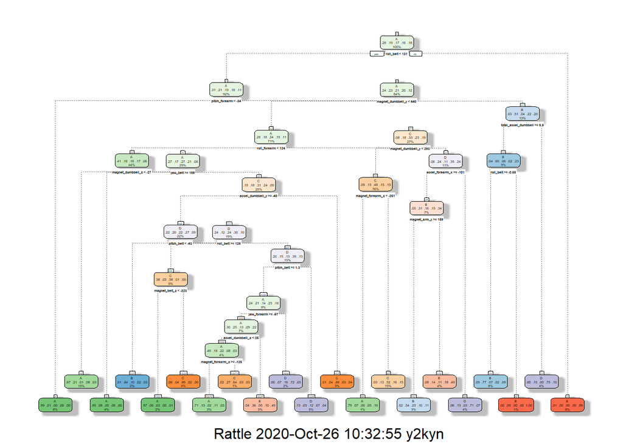

```r
# Training on Recursive Partition and Regression Trees Model #
mdl_rpart <- rpart(classe ~ ., data = trngDS,
                   control = rpartCtrl)

# Plots the trained rpart() model as a dendrogram #
fancyRpartPlot(mdl_rpart)
```

```r
# Predicted results from testing data Set #
predicted_rpart <- predict(mdl_rpart, newdata = tstngDS, type = "class")

# Produce Confusion Matrix to compare the predicted vs actuals of testing data #
# set  #
cm_rpart <- confusionMatrix(reference = tstngDS$classe, data = predicted_rpart,
                            mode = "everything")

# Recursive Partition and Regression Trees Model Confusion Matrix Summary #
cm_rpart
```

```
## Confusion Matrix and Statistics
##
##           Reference
## Prediction   A   B   C   D   E
##          A 990 147  12  68  29
##          B  22 372  53  25  35
##          C  38 106 566  81  88
##          D  43  53  38 423  41
##          E  23  81  15  46 528
##
## Overall Statistics
##
##                Accuracy : 0.7339
##                  95% CI : (0.7197, 0.7477)
##     No Information Rate : 0.2845
##     P-Value [Acc > NIR] : < 2.2e-16
##
##                   Kappa : 0.6623
##
##  Mcnemar's Test P-Value : < 2.2e-16
##
## Statistics by Class:
##
##                      Class: A Class: B Class: C Class: D Class: E
## Sensitivity            0.8871  0.49012   0.8275   0.6579   0.7323
## Specificity            0.9088  0.95733   0.9034   0.9466   0.9485
## Pos Pred Value         0.7945  0.73373   0.6439   0.7074   0.7619
## Neg Pred Value         0.9529  0.88671   0.9612   0.9338   0.9402
## Precision              0.7945  0.73373   0.6439   0.7074   0.7619
## Recall                 0.8871  0.49012   0.8275   0.6579   0.7323
## F1                     0.8383  0.58768   0.7242   0.6817   0.7468
## Prevalence             0.2845  0.19347   0.1744   0.1639   0.1838
## Detection Rate         0.2524  0.09483   0.1443   0.1078   0.1346
## Detection Prevalence   0.3176  0.12924   0.2241   0.1524   0.1767
## Balanced Accuracy      0.8979  0.72373   0.8654   0.8023   0.8404
```

### Training on Random Forest Model & Predicting on Test Data Set

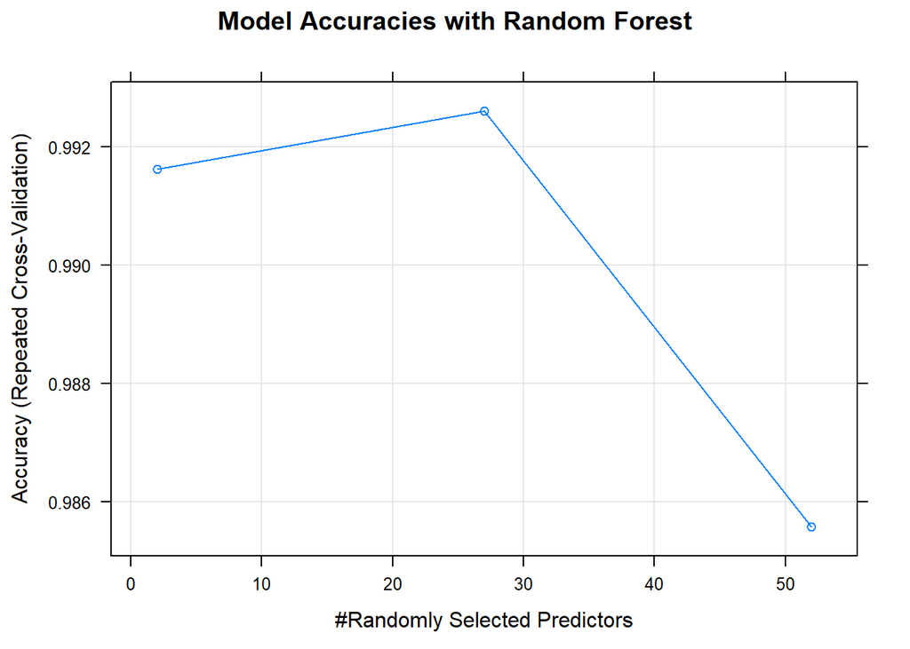

```r
# Training on Random Forrest Model#
mdl_rf <- train(classe ~ ., data = trngDS, method = "rf", trControl = fitCtrl)

# Plot Randomly Selected Predictors vs Accuracy #
plot(mdl_rf, main = "Model Accuracies with Random Forest")
```

```r
# Predicted results from testing data set #
predicted_rf <- predict(mdl_rf, newdata = tstngDS)

# Produce Confusion Matrix to compare the predicted vs actuals of testing data #
# set  #
cm_rf <- confusionMatrix(reference = tstngDS$classe, data = predicted_rf,
                         mode = "everything")

# Random Forest Model Confusion Matrix Summary #
cm_rf
```

```
## Confusion Matrix and Statistics
##
##           Reference
## Prediction    A    B    C    D    E
##          A 1113    2    0    0    0
##          B    3  756    2    0    1
##          C    0    1  679    3    1
##          D    0    0    3  639    4
##          E    0    0    0    1  715
##
## Overall Statistics
##
##                Accuracy : 0.9946
##                  95% CI : (0.9918, 0.9967)
##     No Information Rate : 0.2845
##     P-Value [Acc > NIR] : < 2.2e-16
##
##                   Kappa : 0.9932
##
##  Mcnemar's Test P-Value : NA
##
## Statistics by Class:
##
##                      Class: A Class: B Class: C Class: D Class: E
## Sensitivity            0.9973   0.9960   0.9927   0.9938   0.9917
## Specificity            0.9993   0.9981   0.9985   0.9979   0.9997
## Pos Pred Value         0.9982   0.9921   0.9927   0.9892   0.9986
## Neg Pred Value         0.9989   0.9991   0.9985   0.9988   0.9981
## Precision              0.9982   0.9921   0.9927   0.9892   0.9986
## Recall                 0.9973   0.9960   0.9927   0.9938   0.9917
## F1                     0.9978   0.9941   0.9927   0.9915   0.9951
## Prevalence             0.2845   0.1935   0.1744   0.1639   0.1838
## Detection Rate         0.2837   0.1927   0.1731   0.1629   0.1823
## Detection Prevalence   0.2842   0.1942   0.1744   0.1647   0.1825
## Balanced Accuracy      0.9983   0.9971   0.9956   0.9958   0.9957
```

```r
# Accuracy of the Random Forest Model on testing data set #
accuracy <- as.numeric(cm_rf$overall["Accuracy"])

# Out of sample error for Random Forest Model on testing data set#
ose <- 1 - accuracy

# Change both of the values above into scientific notation #
accuracy <- scientific(accuracy, digits = 4)
ose <- scientific(ose, digits = 4)
```

### Training on gbm() Model and Predicting on Test Data Set

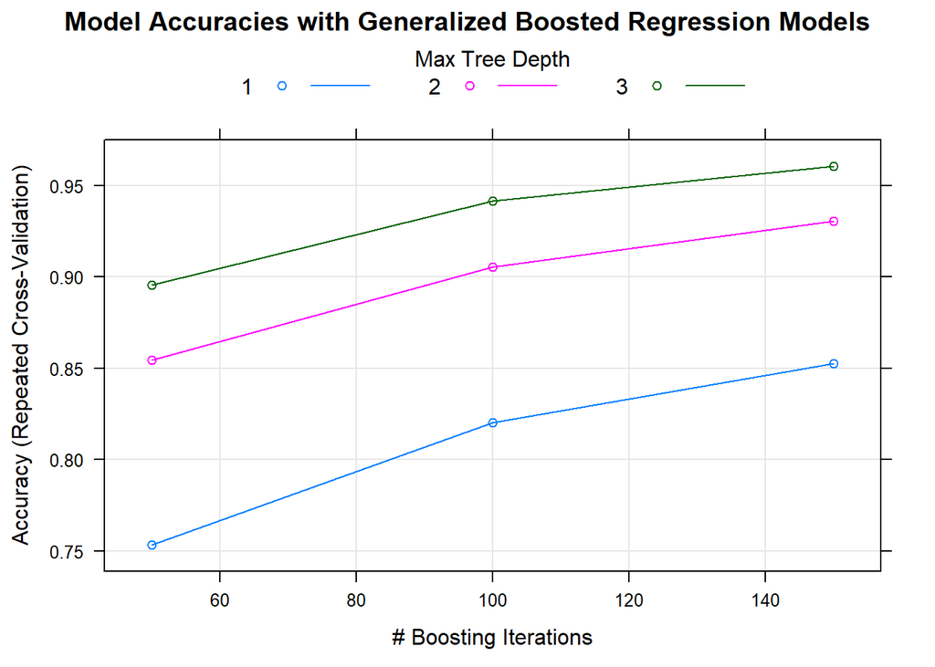

```r
# Training on Generalized Boosted Regression Models #
mdl_gbm <- train(classe ~ ., data = trngDS, method = "gbm", trControl = fitCtrl,
                 verbose = FALSE)

# Plot Boosting Iterations vs Accuracy
plot(mdl_gbm,
     main = "Model Accuracies with Generalized Boosted Regression Models")
```

```r
# Predicted results from testing data set #
predicted_gbm <- predict(mdl_gbm, newdata = tstngDS)

# Produce Confusion Matrix to compare the predicted vs actuals of testing data #
# set  #
cm_gbm <- confusionMatrix(reference = tstngDS$classe, data = predicted_gbm,
                         mode = "everything")

# Generalized Boosted Regression Models Confusion Matrix Summary #
cm_gbm
```

```
## Confusion Matrix and Statistics
##
##           Reference
## Prediction    A    B    C    D    E
##          A 1097   22    0    1    1
##          B   13  722   15    4    3
##          C    4   14  659   17    4
##          D    2    0    8  619   16
##          E    0    1    2    2  697
##
## Overall Statistics
##
##                Accuracy : 0.9671
##                  95% CI : (0.961, 0.9725)
##     No Information Rate : 0.2845
##     P-Value [Acc > NIR] : < 2.2e-16
##
##                   Kappa : 0.9584
##
##  Mcnemar's Test P-Value : 0.002187
##
## Statistics by Class:
##
##                      Class: A Class: B Class: C Class: D Class: E
## Sensitivity            0.9830   0.9513   0.9635   0.9627   0.9667
## Specificity            0.9914   0.9889   0.9880   0.9921   0.9984
## Pos Pred Value         0.9786   0.9538   0.9441   0.9597   0.9929
## Neg Pred Value         0.9932   0.9883   0.9922   0.9927   0.9925
## Precision              0.9786   0.9538   0.9441   0.9597   0.9929
## Recall                 0.9830   0.9513   0.9635   0.9627   0.9667
## F1                     0.9808   0.9525   0.9537   0.9612   0.9796
## Prevalence             0.2845   0.1935   0.1744   0.1639   0.1838
## Detection Rate         0.2796   0.1840   0.1680   0.1578   0.1777
## Detection Prevalence   0.2858   0.1930   0.1779   0.1644   0.1789
## Balanced Accuracy      0.9872   0.9701   0.9757   0.9774   0.9826
```

From the confusion matrix summary of all three model, it is apparent that the random forest model is most accurate and thus the model to use in making the prediction on the testing data frame that was set aside, with an accuracy of 9.946e-01 and an out of sample error of 5.353e-03.

### Prediction on Test Data Set Put Aside

```r
# Uses the trained Random Forest Model to predict the testing data set that was #
# put aside. #
predictions <- predict(mdl_rf, newdata = tstng)

# Display the predictions made on the testing data set that was put aside #
predictions
```

```
##  [1] B A B A A E D B A A B C B A E E A B B B
## Levels: A B C D E
```